# Problem set 2

# Details

## Instructions

In addition to running the code, you will need to do two things: either write in complete sentences a response or write R code to fill in a chunk.

- “xxxxx” = Write, in complete English sentences, your response. 1-2 sentences is sufficient.
- “**Plot**” = Write R code in the chunk corresponding to the instructions.

# Analyzing CMPD Traffic Stops

For this problem set, we’ll examine a data set of stops by the Charlotte-Mecklenburg Police Department (CMPD).

Our focus will be to understand what factors are related to whether someone is searched or not for a traffic stop.

For our data set, you’ll load the csv file we saved in the setup. This should be in your data folder.

```r
library(tidyverse)
library(scales)
library(ggspatial) # make sure to install if you don't have it

df <- read_csv("./data/Officer_Traffic_Stops.csv")
```

## Demographics of drivers (1 point)

First, look at the data using the `glimpse()` function from `dplyr`

```r
glimpse(df)
```

```
## Observations: 68,488
## Variables: 17
## $ Month_of_Stop            <chr> "2017/06", "2017/06", "2017/06", "2017/…
## $ Reason_for_Stop          <chr> "Vehicle Regulatory", "Vehicle Regulato…
## $ Officer_Race             <chr> "White", "White", "White", "White", "Wh…
## $ Officer_Gender           <chr> "Female", "Male", "Male", "Male", "Male…
## $ Officer_Years_of_Service <dbl> 3, 2, 5, 10, 2, 3, 2, 5, 25, 10, 25, 12…
## $ Driver_Race              <chr> "Black", "Black", "Black", "White", "Bl…
## $ Driver_Ethnicity         <chr> "Non-Hispanic", "Non-Hispanic", "Non-Hi…
## $ Driver_Gender            <chr> "Male", "Male", "Male", "Male", "Female…
## $ Driver_Age               <dbl> 23, 36, 45, 30, 37, 50, 50, 19, 41, 22,…
## $ Was_a_Search_Conducted   <chr> "No", "No", "No", "No", "No", "No", "No…
## $ Result_of_Stop           <chr> "Verbal Warning", "Verbal Warning", "Ve…
## $ CMPD_Division            <chr> "North Tryon Division", "Central Divisi…
## $ ObjectID                 <dbl> 3001, 3002, 3003, 3004, 3005, 3006, 300…
## $ CreationDate             <dttm> 2019-02-16 10:01:44, 2019-02-16 10:01:…
## $ Creator                  <chr> "CharlotteNC", "CharlotteNC", "Charlott…
## $ EditDate                 <dttm> 2019-02-16 10:01:44, 2019-02-16 10:01:…
## $ Editor                   <chr> "CharlotteNC", "CharlotteNC", "Charlott…
```

Notice the different variable types: character (chr), num (numeric), and datetime (POSIXct).

Let’s consider our target variable: `Was_a_Search_Conducted`.

**Plot** a bar chart that counts the number of records by `Was_a_Search_Conducted`.

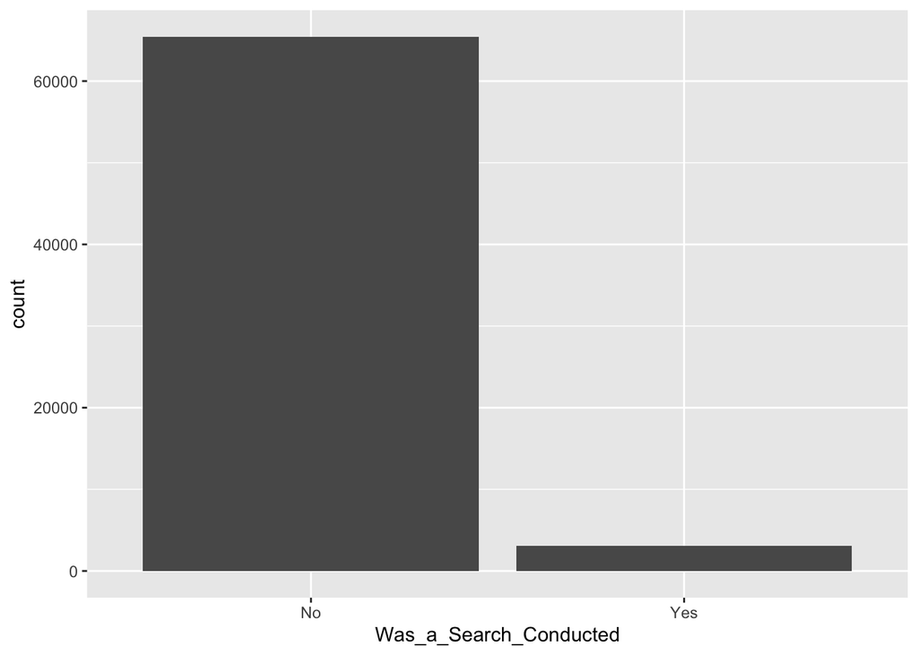

```r
df %>%
  ggplot(aes(x = Was_a_Search_Conducted)) +
  geom_bar()
```

**It’s okay if students use `geom_col()` instead of `geom_bar()`**

How well balanced is the data set by this field? xxxxx

**The data is imbalanced. There are much fewer Yes results than No.**

Next, let’s consider the age range of the driver.

**Plot** a histogram of `Driver_Age`. Determine an appropriate number of bins.

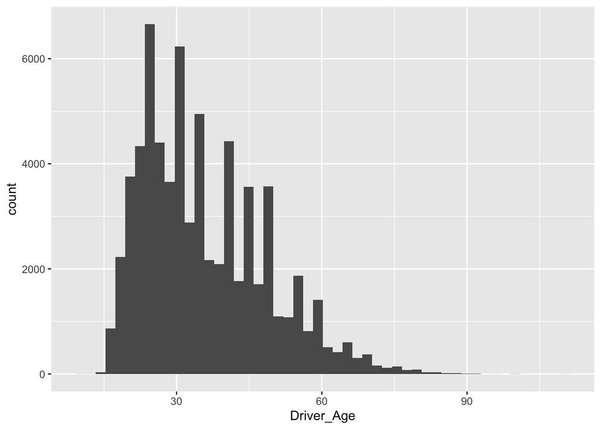

```r
df %>%
  ggplot(aes(x = Driver_Age)) +
  geom_histogram(bins = 50)
```

Once you go above (around) 40-50 bins, you’ll notice some points stick out.

What is happening? xxxxx

**Answer: It appears that there are some ages that are occur more often than ages next to them (e.g., 20, 25, 30, 35, 40). This seems to suggest that sometimes these ages are rounded as we would have no reason to suspect the data truly would be larger just for every five years.**

**Plot** a density plot of `Driver_Age`. Add in a fill to be “lightblue”. Determine an appropriate kernel density to use (`adjust`).

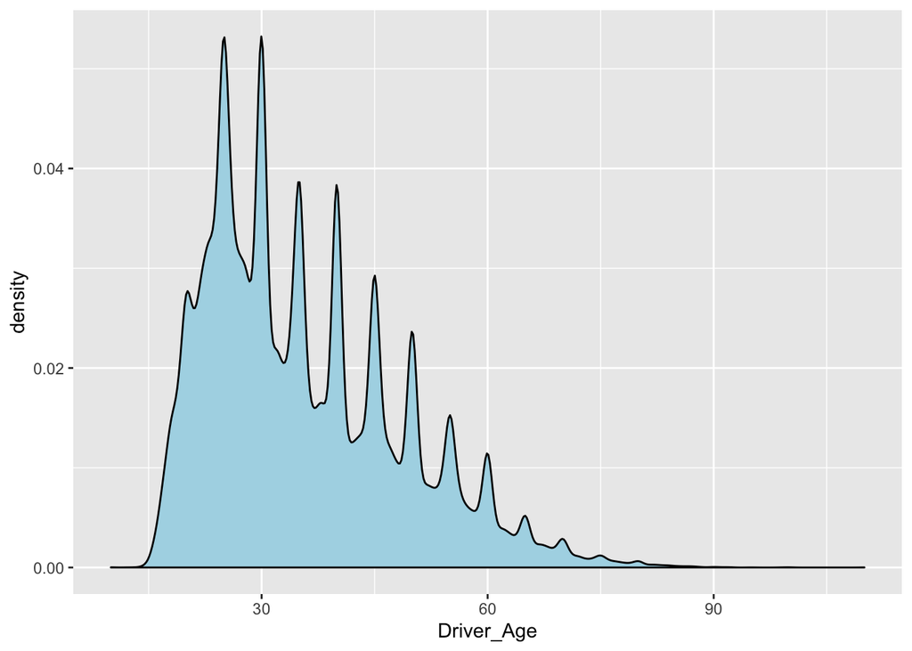

```r
df %>%
  ggplot(aes(x = Driver_Age)) +
  geom_density(adjust = 0.5, fill = "lightblue")
```

**Plot** a box plot with `Was_a_Search_Conducted` on the x-axis and `Driver_Age` on the y-axis.

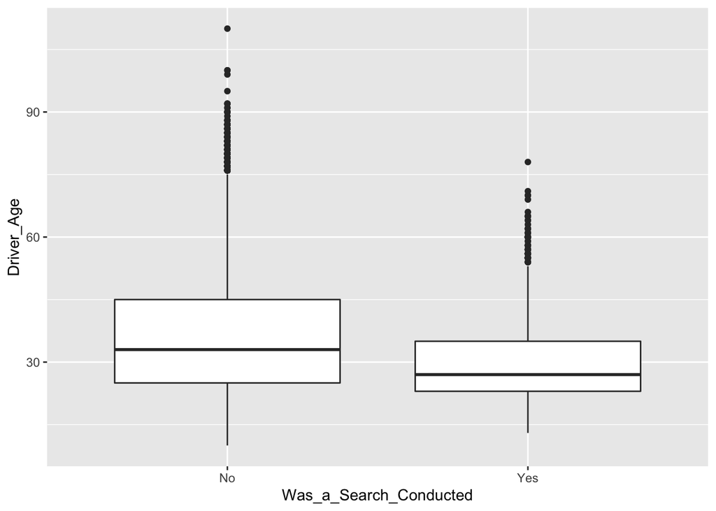

```r
ggplot(df, aes(x = Was_a_Search_Conducted, y = Driver_Age)) +
  geom_boxplot()
```

**Plot** a violin plot.

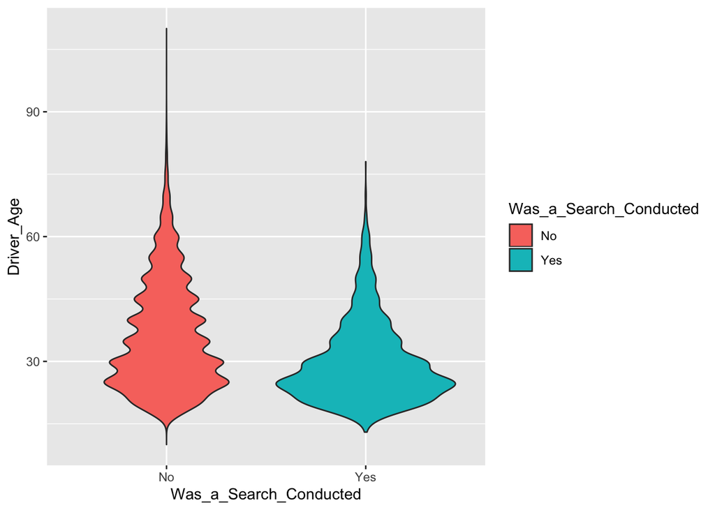

```r
ggplot(df, aes(x = Was_a_Search_Conducted, y = Driver_Age, fill = Was_a_Search_Conducted)) +
  geom_violin()
```

From the plots above, do you think the age of the driver is a significant factor in whether a search was conducted? Why or why not? xxxxx

**Answer: It appears that the searches were conducted on a slightly younger population than the population that was not searched. But other answers could include no relationship, need better plot to make a judgment.**

## Date of stop (1 point)

Let’s plot the number of stops by time.

Recalling part one, the `Month_of_Stop` variable is a character, not a date variable. The datatime’s are simply when the data was collected; not when the stop occurred. Therefore, we’ll need to convert the `Month_of_Stop` variable from a character to a Date format.

Let’s first cleanup the date field using `tidyverse` packages like `stringr` and `lubridate`.

```r
library(stringr); library(lubridate)
# see https://dsba5122fall2019.slack.com/archives/CLUCHHQPJ/p1569273552006200
df <- mutate(df, Month_of_Stop = str_replace_all(Month_of_Stop, "/","-")) # replace "/" with "-"
df <- mutate(df, Month_of_Stop = paste0(df$Month_of_Stop,"-01")) # add in day
df <- mutate(df, Date = ymd(Month_of_Stop)) # created a date field
```

**Plot** a line chart with the number of traffic stops for each month (hint: start with the `count()` function by Date then feed into ggplot. Remember the count variable is named ‘n’.).

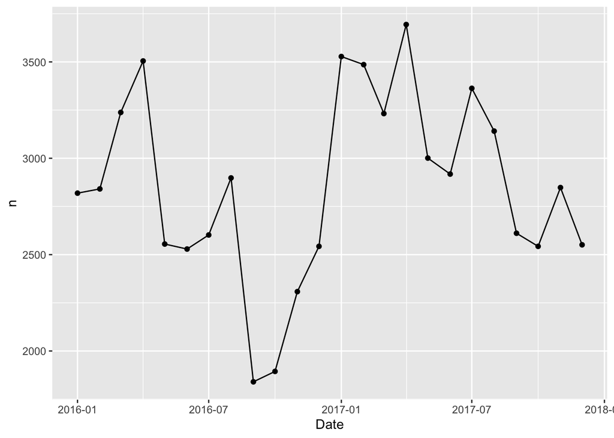

```r
count(df, Date) %>%
  ggplot(aes(x = Date, y = n)) +
  geom_point() +
  geom_line()
```

What is the trend (i.e., long term rate of change) of the number of traffic stops in Charlotte? xxxxx

**Answer: The long term trends is flat but there were short term fluctuations (e.g., dropped in late 2016 but then increased in 2017)** https://dsba5122fall2019.slack.com/archives/CLUCHHQPJ/p1569273552006200 **Plot** the same plot but add in `facet_wrap()` by the `Reason_for_Stop` variable.

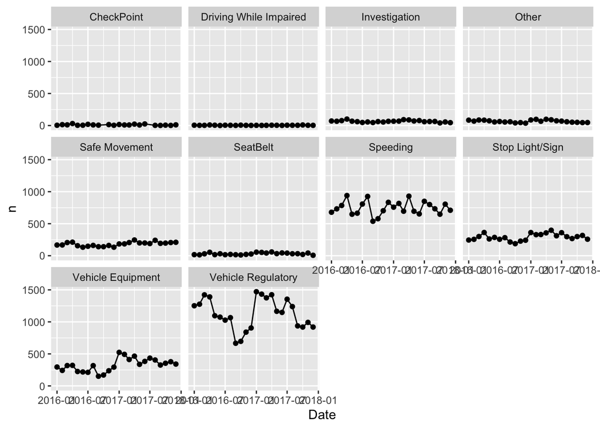

```r
count(df, Date, Reason_for_Stop) %>%
  ggplot(aes(x = Date, y = n)) +
  geom_point() +
  geom_line() +
  facet_wrap(~Reason_for_Stop)
```

What is a problem with this plot? xxxxx

**Answer: Since several of the variables are very small, they appear like flat lines given the same y-axis scale for the facets (multiple graphs).**

To address this problem, you will need to figure out how to adjust the scale. To do this, you need to use R’s documentation to see whether there is a parameter in `facet_wrap`.

Go to your RStudio console and type `?facet_wrap`.

What parameter allows you to modify the scales of `facet_wrap`? xxxxx

**Answer: scales parameter**

**Plot** the same plot but with a free y-axis scale.

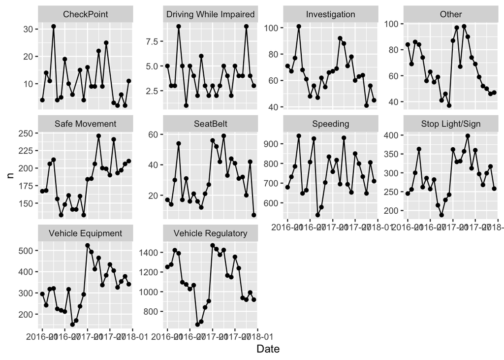

```r
count(df, Date, Reason_for_Stop) %>%
  ggplot(aes(x = Date, y = n)) +
  geom_point() +
  geom_line() +
  facet_wrap(~Reason_for_Stop, scale = "free_y")
```

Which type of police stop has had the most volatility (i.e., big swings in number of stops)? xxxxx

**Answer: Answers can vary. True answer is that it’s too difficult to assess with different label. True answer would be Vehicle Regulatory since it’s the largest category.**

What is one problem with allowing the y-axis be free? xxxxx

**Answer: it’s difficult to compare horizontally (across) plots. For example, Speeding is on a different scale than SeatBelts**

Small multiples tends to be less effective when each of the variables are on different scales or magnitudes.

Let’s consider instead CMPD traffic stops but by CMPD division. These are more even spread by division than the type of stop.

**Plot** a line chart (optional points too) for stops by `Date` (x axis) and `CMPD_Division` (y axis). (hint: to modify how the date is shown, use the layer `scale_x_date(date_labels = "%Y") +` to show only the year. Feel free to modify by looking at `?scale_x_date`.)

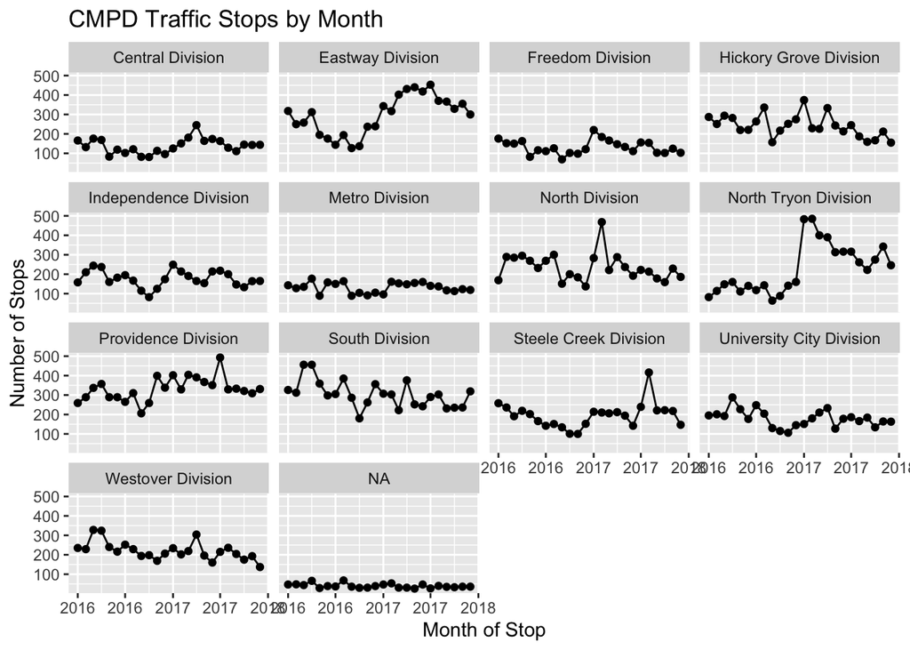

```r
df %>%
  count(Date, CMPD_Division) %>%
  ggplot(aes(x = Date, y = n)) +
  geom_line() +
  geom_point() +
  scale_x_date(date_labels = "%Y") +
  labs(x = "Month of Stop",
       y = "Number of Stops",
       title = "CMPD Traffic Stops by Month") +
  facet_wrap(.~CMPD_Division)
```

What are three observations you can make about the number of police stops by divison? (hint: just write about what’s in the data.)

Next, this doesn’t help tell us where these areas are. For that, let’s use a shape file to create a chloropleth of stops by division.

## Geography (1 point)

For this example, we’ll create a cholorpleth for the number of police stops by police division.

To do this, we need to use the `sf` package. (For help along the way, see [this tutorial](http://strimas.com/r/tidy-sf/) on `sf` package.)

```r
library(sf); library(viridis)
cmpd <- st_read("./data/CMPD_Police_Divisions.shp")
```

Note that while we have five files, we only load in the shapefile (`.shp`) file. This is typical but know that to use this file you would need the other four files in the same folder as your shapefile.

**Plot** cmpd using the `geom_sf` package where you provide `fill = DNAME` as the only aesthetic. Add in a title saying “CMPD Divisions” and add the `theme_bw()` theme to make translate the file into the black and white template.

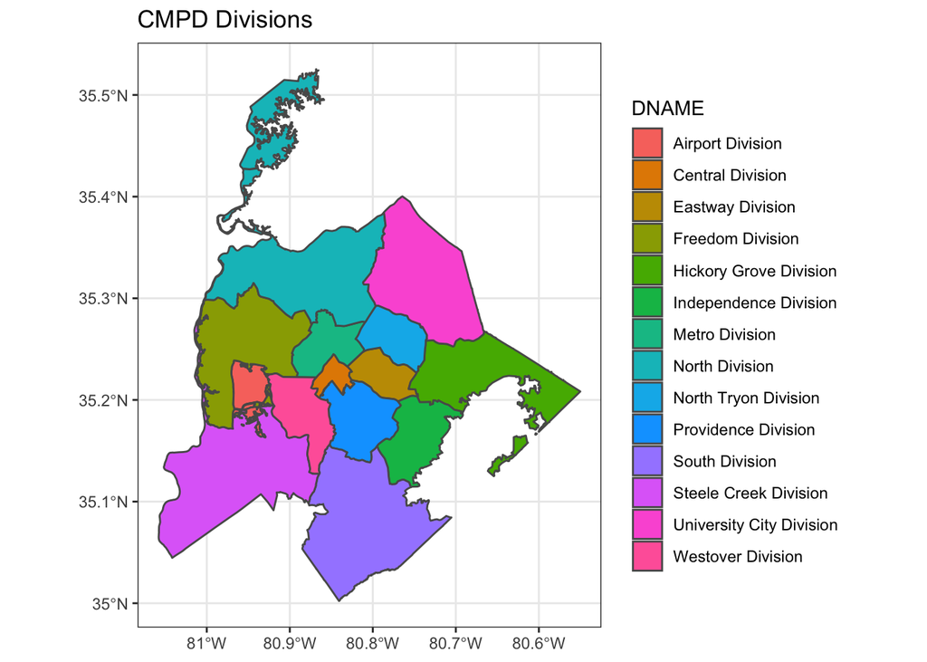

```r
cmpd %>%
  ggplot() +
  geom_sf(aes(fill = DNAME)) +
  labs(title = "CMPD Divisions") +
  theme_bw()
```

One problem with this map is it’s hard to read the division names. That is, it may be better to remove the legend and put the labels of each division within the plot.

To do this, we can use the related `geom_sf_label()` geom, using the name of the division as the aesthetic label.

**Plot** the same plot from above but with the name of the division as the label.

1. You’ll likely need to reduce the size of the label, using the `size` paramater. You should likely set the `size` to under 2.
2. Make sure to remove the legend (it’s redundant and no longer necessary).
3. Create a new variable named `Name` that removes the term " Division". This term is redundant and takes up a lot of space in the labels from `DNAME`. To do this step, use this snippet of code at the top of your pipeline:

```r
cmpd %>%
  mutate(Name = as.character(DNAME)) %>%
  mutate(Name = str_replace_all(Name, " Division",""))
```

4. Save it as an object named `g`. Make sure to call it once so that the map will output.

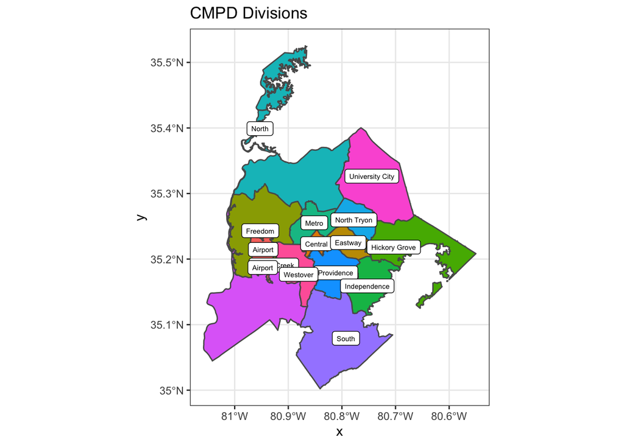

```r
g <- cmpd %>%
  mutate(Name = as.character(DNAME)) %>%
  mutate(Name = stringr::str_replace_all(Name, " Division","")) %>%
  ggplot() +
  geom_sf(aes(fill = Name)) +
  geom_sf_label(aes(label = Name), size = 2) +
  labs(title = "CMPD Divisions") +
  theme_bw() +
  theme(legend.position = "none")

g
```

**Plot**: Now let’s change the projection type. Simply add in `coord_sf(crs = st_crs(102003))` as an additional layer to `g`.

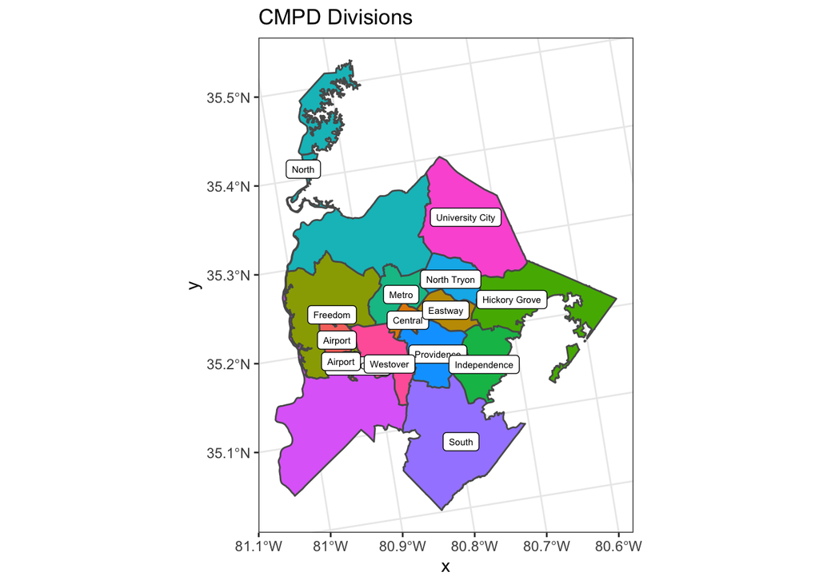

```r
g + coord_sf(crs = st_crs(102003)) # Albers projection
```

Do you notice any difference between the two maps? xxxxx

**Answer: not much. The plots shifted some but these changes typically have a larger impact, i.e., show up on a country or continent level, not a county/city level**

## Advanced Plot: (0.5 point)

Now, let’s create a chloropleth. Below is the code to create an advanced plot.

In this problem, you need to explain what each step below is doing:

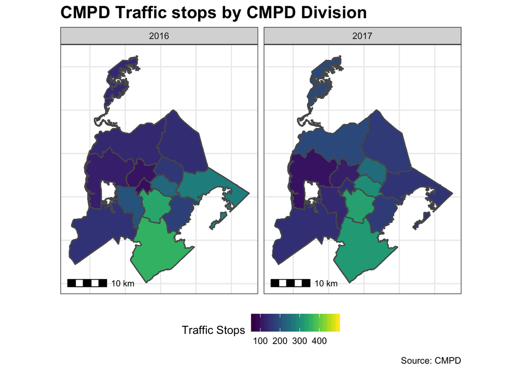

```r
cmpd_chloropleth <- cmpd %>%
  mutate(CMPD_Division = as.character(DNAME)) %>%
  inner_join(count(df, CMPD_Division, Date), by = "CMPD_Division") %>%
  mutate(Year = lubridate::year(Date)) %>%
  ggplot() +
  geom_sf(aes(fill = n)) +
  scale_fill_viridis("Traffic Stops", labels = scales::comma) +
  labs(title = "CMPD Traffic stops by CMPD Division",
       caption = "Source: CMPD") +
  annotation_scale(location = "bl", width_hint = 0.2) +
  facet_wrap(~Year) +
  theme_bw() +
  theme(legend.position = "bottom",
        plot.title = element_text(face = "bold", size = rel(1.5)),
        axis.text.x=element_blank(),
        axis.text.y=element_blank(),
        axis.ticks.x=element_blank(),
        axis.ticks.y=element_blank())

cmpd_chloropleth
```

```r
ggsave(cmpd_chloropleth, filename = "cmpd_chloropleth.pdf",
       width = 7, height = 5, units = "in")
ggsave(cmpd_chloropleth, filename = "cmpd_chloropleth.png",
       width = 7, height = 5, units = "in")
```

## Choosing a ggplot extensions (1 point)

Go to [ggextensions website](https://www.ggplot2-exts.org/). Then click Galleries to explore the different ggplot extensions. Scroll through and see if any catch your eye.

Now, select **one** of the ggextension libraries below and install the package (through CRAN):

- [`ggridges`](https://cran.r-project.org/web/packages/ggridges/vignettes/introduction.html) / [example to recreate](https://cran.r-project.org/web/packages/ggridges/vignettes/introduction.html#varying-fill-colors-along-the-x-axis)[^1]
- [`ggalt`](https://github.com/hrbrmstr/ggalt) / [example to recreate](https://github.com/hrbrmstr/ggalt#horzon-chart)[^2]
- [`ggrepel`](https://github.com/slowkow/ggrepel) / [example to recreate](https://github.com/slowkow/ggrepel/blob/master/vignettes/ggrepel.md#align-labels-on-the-left-or-right-edge)
- [`ggstatsplot`](https://github.com/IndrajeetPatil/ggstatsplot) / [example to recreate](https://github.com/IndrajeetPatil/ggstatsplot#ggscatterstats)[^3]

## Intro to interactivity (0.5 points)

For even more fun, **plot** an interactive HTML plot using the code for any of the plots above (fair warning, some of the ggextensions may not work well).

The easiest way to do this is to use the `plotly` package (install it with the “Packages” panel in RStudio), and then to use its `ggplotly()` function.

I’ve given you some commented-out code below (commented out so that R doesn’t yell at you about the code not working when you knit).

Also, check out [the documentation](https://plot.ly/ggplot2/), especially [this page](https://plot.ly/ggplot2/interactive-tooltip/) about customizing the tooltips that show up when you hover over points or areas.

```r
# library(plotly)
#
# my_cool_plot <- ggplot(...)
#
# my_cool_plot
#
# ggplotly(my_cool_plot)
```

[^1]: Run both plots. Make sure to install the `viridis` package or else you’ll get an error!
[^2]: Make sure to install `hrbrthemes`!
[^3]: Run all three examples in the `ggscatterstats` section.